# MPDW 4

Berliana Destari Hermansyah

2025-09-15

### 1 Import Data

```r
library(dLagM)
library(dynlm)
library(MLmetrics)
library(lmtest)
library(car)
dataAQI <- read.csv("C:/Users/MSI I5/Downloads/NewDelhi_Air_quality.csv")
dataAQI
```

```
##     X  AQI       CO      datetime        no2       o3      pm10     pm25
## 1   0 30.2 198.6027 2022-10-21:18 0.04685717 55.78995 10.486722 5.637410
## 2   1 28.2 197.6013 2022-10-21:19 0.04645554 54.93164 10.719325 4.618169
## 3   2 26.6 198.6027 2022-10-21:20 0.04685717 54.64554 11.155578 3.520902
## 4   3 25.0 201.9405 2022-10-21:21 0.04819594 55.07469 11.116206 2.225919
## 5   4 26.0 205.2784 2022-10-21:22 0.04886533 55.78995 10.405250 1.979471
## 6   5 26.0 208.6163 2022-10-21:23 0.05020411 56.50520  9.402518 1.792677
## 7   6 26.0 208.6163 2022-10-22:00 0.05020411 55.78995  8.482822 1.752237
## 8   7 24.0 205.2784 2022-10-22:01 0.05020411 52.92892  7.586667 1.858459
## 9   8 23.0 200.2716 2022-10-22:02 0.04685717 50.06790  7.636587 2.208076
## 10  9 24.0 196.9338 2022-10-22:03 0.04417961 51.49841  8.487648 2.476681
## 11 10 25.0 198.6027 2022-10-22:04 0.04284084 53.64418  9.357371 2.585729
## 12 11 26.0 200.2716 2022-10-22:05 0.04049798 55.78995 10.338728 2.390081
## 13 12 27.0 203.6095 2022-10-22:06 0.04016329 59.36623 10.523314 2.086022
## 14 13 29.0 205.2784 2022-10-22:07 0.03882451 62.22725 10.635970 1.937047
```

[output cut: 131 more lines]

```r
str(dataAQI)
```

```
## 'data.frame':    72 obs. of  12 variables:
##  $ X              : int  0 1 2 3 4 5 6 7 8 9 ...
##  $ AQI            : num  30.2 28.2 26.6 25 26 26 26 24 23 24 ...
##  $ CO             : num  199 198 199 202 205 ...
##  $ datetime       : chr  "2022-10-21:18" "2022-10-21:19" "2022-10-21:20" "2022-10-21:21" ...
##  $ no2            : num  0.0469 0.0465 0.0469 0.0482 0.0489 ...
##  $ o3             : num  55.8 54.9 54.6 55.1 55.8 ...
##  $ pm10           : num  10.5 10.7 11.2 11.1 10.4 ...
##  $ pm25           : num  5.64 4.62 3.52 2.23 1.98 ...
##  $ so2            : num  0.387 0.41 0.402 0.376 0.339 ...
##  $ timestamp_local: chr  "2022-10-21T23:00:00" "2022-10-22T00:00:00" "2022-10-22T01:00:00" "2022-10-22T02:00:00" ...
##  $ timestamp_utc  : chr  "2022-10-21T18:00:00" "2022-10-21T19:00:00" "2022-10-21T20:00:00" "2022-10-21T21:00:00" ...
##  $ ts             : int  1666375200 1666378800 1666382400 1666386000 1666389600 1666393200 1666396800 1666400400 1666404000 1666407600 ...
```

```r
dataAQI
```

```
##     X  AQI       CO      datetime        no2       o3      pm10     pm25
## 1   0 30.2 198.6027 2022-10-21:18 0.04685717 55.78995 10.486722 5.637410
## 2   1 28.2 197.6013 2022-10-21:19 0.04645554 54.93164 10.719325 4.618169
## 3   2 26.6 198.6027 2022-10-21:20 0.04685717 54.64554 11.155578 3.520902
## 4   3 25.0 201.9405 2022-10-21:21 0.04819594 55.07469 11.116206 2.225919
## 5   4 26.0 205.2784 2022-10-21:22 0.04886533 55.78995 10.405250 1.979471
## 6   5 26.0 208.6163 2022-10-21:23 0.05020411 56.50520  9.402518 1.792677
## 7   6 26.0 208.6163 2022-10-22:00 0.05020411 55.78995  8.482822 1.752237
## 8   7 24.0 205.2784 2022-10-22:01 0.05020411 52.92892  7.586667 1.858459
## 9   8 23.0 200.2716 2022-10-22:02 0.04685717 50.06790  7.636587 2.208076
## 10  9 24.0 196.9338 2022-10-22:03 0.04417961 51.49841  8.487648 2.476681
## 11 10 25.0 198.6027 2022-10-22:04 0.04284084 53.64418  9.357371 2.585729
## 12 11 26.0 200.2716 2022-10-22:05 0.04049798 55.78995 10.338728 2.390081
## 13 12 27.0 203.6095 2022-10-22:06 0.04016329 59.36623 10.523314 2.086022
## 14 13 29.0 205.2784 2022-10-22:07 0.03882451 62.22725 10.635970 1.937047
```

[output cut: 131 more lines]

### 2 Pembagian Data

```r
#Split Data
train <- dataAQI[1:50,]
test <- dataAQI[51:71,]
```

```r
#Data Time Series
train.ts<-ts(train)
test.ts<-ts(test)
data.ts<-ts(dataAQI)
```

```r
# Model Koyck dengan intercept
model.koyck <- koyckDlm(
  x = train$pm10,
  y = train$AQI,
  intercept = TRUE
)

# Lihat ringkasan model
summary(model.koyck)
```

```
##
## Call:
## "Y ~ (Intercept) + Y.1 + X.t"
##
## Residuals:
##      Min       1Q   Median       3Q      Max
## -2.10650 -0.52819  0.09332  0.52263  2.12942
##
## Coefficients:
##             Estimate Std. Error t value Pr(>|t|)
## (Intercept)  0.46475    1.91295   0.243   0.8091
## Y.1          0.89937    0.05745  15.654   <2e-16 ***
## X.t          0.24454    0.11332   2.158   0.0362 *
## ---
## Signif. codes:  0 '***' 0.001 '**' 0.01 '*' 0.05 '.' 0.1 ' ' 1
##
## Residual standard error: 0.9137 on 46 degrees of freedom
## Multiple R-Squared: 0.843,   Adjusted R-squared: 0.8362
## Wald test: 123.6 on 2 and 46 DF,  p-value: < 2.2e-16
##
## Diagnostic tests:
## NULL
##
##                             alpha      beta       phi
## Geometric coefficients:  4.618624 0.2445437 0.8993738
```

```r
AIC(model.koyck)
```

```
## [1] 135.1158
```

```r
BIC(model.koyck)
```

```
## [1] 142.6831
```

Persamaan model (estimasi Koyck):
$$\hat{Y}_t = 0.4648 + 0.2445\,X_t +
0.8994\,Y_{t-1}$$

- (Intercept) = 0.46475 ; Std. Error = 1.91295 ; p-value = 0.8091 (tidak signifikan)
- Y_{t-1} = 0.89937 ; Std. Error = 0.05745 ; p-value < 2e-16 (sangat signifikan) ***
- X_t (pm10) = 0.24454 ; Std. Error = 0.11332 ; p-value = 0.0362 (signifikan pada α = 5%) *
- Dari hasil tersebut, peubah X_t (pm10) dan Y_{t-1} memiliki p-value < 0.05 (untuk X_t p = 0.0362; untuk Y_{t-1} p < 2e-16). Ini menunjukkan bahwa keduanya berpengaruh signifikan terhadap Y (AQI) pada data pelatihan.
- Koefisien short-run untuk pm10 sebesar **0.2445** berarti: kenaikan 1 satuan pm10 diasosiasikan dengan kenaikan AQI sebesar ~0.2445 poin saat ini, ceteris paribus.
- Koefisien lag AQI (Y_{t-1}) sebesar **0.8994** menunjukkan **persistensi tinggi**: ~89.94% dari nilai AQI sebelumnya terbawa ke periode sekarang. Ini menandakan akumulasi efek polusi antar periode.
- **Long-run effect** (akumulasi efek pm10 lewat mekanisme lag) dihitung:
  $$\text{Long-run effect} = \frac{\beta}{1-\phi} = \frac{0.24454}{1 -
  0.89937} \approx 2.4301.$$
  Artinya: kenaikan 1 satuan pm10 akan menaikkan AQI sekitar **2.43 poin** dalam jangka panjang setelah efek lag terakumulasi.
- R^2 = 0.843 mengindikasikan model menjelaskan ~84.3% variasi AQI pada sample training dengan fit yang baik.

### 3 Peramalan dan Akurasi

```r
fore.koyck <- forecast(model = model.koyck, x=test$pm10, h=21)
fore.koyck
```

```
## $forecasts
##  [1] 26.86415 26.70789 26.42268 25.96419 25.48302 25.25711 25.31242 25.29826
##  [9] 24.97439 24.62569 24.37455 24.31811 24.47430 24.82965 25.30333 25.83934
## [17] 26.31156 26.67759 27.20672 27.89228 28.69175
##
## $call
## forecast.koyckDlm(model = model.koyck, x = test$pm10, h = 21)
##
## attr(,"class")
## [1] "forecast.koyckDlm" "dLagM"
```

1. Prediksi awal sekitar 26.86 lalu sempat turun ke titik terendah sekitar 24.32–24.37 (periode ke-11/12).
2. Setelah itu, AQI diperkirakan naik kembali hingga mencapai 28.69 pada periode ke-21.
3. Pola ini menunjukkan fluktuasi sementara diikuti tren kenaikan jangka menengah.

```r
mape.koyck <- MAPE(fore.koyck$forecasts, test$AQI)
mape.koyck
```

```
## [1] 0.1356715
```

```r
# Akurasi data training
GoF(model.koyck)
```

```
##              n       MAE          MPE       MAPE      sMAPE     MASE      MSE
## model.koyck 49 0.6664077 -0.001004147 0.02460129 0.02449286 1.025243 0.783741
##                   MRAE    GMRAE
## model.koyck 1312584850 13640.51
```

1. Fluktuasi AQI dipengaruhi dinamika pm10; meski ada penurunan di tengah periode, efek lag menyebabkan tren jangka menengah kembali naik.
2. Persistensi tinggi (lag AQI signifikan) membuat perubahan kualitas udara tidak cepat hilang — ada efek bertahan dari polusi.
3. Akurasi model (MAPE ~13.6%) cukup baik, sehingga model layak digunakan untuk monitoring jangka pendek–menengah kualitas udara.

### 4 Regression with Distributed Lag

```r
# Distributed Lag Model dengan 2 lag untuk pm10
model.dlm <- dlm(
  formula = AQI ~ pm10,
  data = train,
  q = 2
)
summary(model.dlm)
```

```
##
## Call:
## lm(formula = as.formula(model.formula), data = design)
##
## Residuals:
##     Min      1Q  Median      3Q     Max
## -4.0646 -1.6424 -0.0113  1.1959  4.8318
##
## Coefficients:
##              Estimate Std. Error t value Pr(>|t|)
## (Intercept) 22.706577   3.067236   7.403 2.95e-09 ***
## pm10.t      -0.009698   0.759464  -0.013    0.990
## pm10.1      -0.235451   1.231705  -0.191    0.849
## pm10.2       0.733060   0.759697   0.965    0.340
## ---
## Signif. codes:  0 '***' 0.001 '**' 0.01 '*' 0.05 '.' 0.1 ' ' 1
##
## Residual standard error: 2.223 on 44 degrees of freedom
## Multiple R-squared:  0.1074, Adjusted R-squared:  0.04654
## F-statistic: 1.765 on 3 and 44 DF,  p-value: 0.1678
##
## AIC and BIC values for the model:
##        AIC      BIC
## 1 218.7361 228.0921
```

Namun, secara keseluruhan, model distributed lag (q = 2) tidak lebih unggul dibandingkan model Koyck, baik dari segi kesesuaian data maupun efisiensi model.

### 5 Peramalan dan Akurasi

```r
fore.dlm <- forecast(model = model.dlm, x=test$pm10, h=21)
fore.dlm
```

```
## $forecasts
##  [1] 26.24038 26.48124 26.96892 27.01404 26.77756 26.23015 25.81447 26.18816
##  [9] 27.03689 27.14715 26.26730 26.02829 26.04425 26.34435 26.75172 27.24313
## [17] 27.59952 27.94105 27.96009 27.58340 27.97356
##
## $call
## forecast.dlm(model = model.dlm, x = test$pm10, h = 21)
##
## attr(,"class")
## [1] "forecast.dlm" "dLagM"
```

```r
mape.dlm <- MAPE(fore.dlm$forecasts, test$AQI)
mape.dlm
```

```
## [1] 0.1723035
```

```r
# Akurasi data training
GoF(model.dlm)
```

```
##            n      MAE          MPE       MAPE      sMAPE     MASE      MSE
## model.dlm 48 1.660592 -0.005954793 0.06050245 0.06046857 2.636751 4.530312
##                 MRAE    GMRAE
## model.dlm 6966171898 33413.54
```

### 6 Lag Optimum

```r
finiteDLMauto(formula = AQI ~ pm10,
              data = train, q.min = 1, q.max = 10,
              model.type = "dlm", error.type = "AIC", trace = TRUE)
```

```
##    q - k    MASE      AIC      BIC    GMRAE   MBRAE R.Adj.Sq    Ljung-Box
## 10    10 2.16194 172.1039 194.0593 91124.18 1.06424  0.33632 4.812253e-08
## 9      9 2.22716 180.8728 201.4356 74215.64 0.79136  0.27380 1.277974e-07
## 8      8 2.38905 193.4694 212.5838 59408.85 1.01124  0.15885 1.224092e-07
## 7      7 2.51798 201.9683 219.5803 46603.42 0.19998  0.08285 5.328739e-09
## 6      6 2.44518 205.7119 221.7696 34798.62 0.50510  0.06769 6.755959e-10
## 5      5 2.57471 209.3756 223.8289 45975.92 0.80324  0.05313 3.880667e-10
## 4      4 2.69699 212.6504 225.4509 65488.67 0.83575  0.04571 1.676695e-10
## 3      3 2.71823 216.6398 227.7407 47789.51 0.84732  0.03624 1.334368e-10
## 2      2 2.63675 218.7361 228.0921 33413.54 0.84533  0.04654 5.237244e-11
## 1      1 2.58999 221.2392 228.8065 34735.08 0.47903  0.05016 8.906054e-11
```

Berdasarkan output tersebut, lag optimum didapatkan ketika lag q =10 Selanjutnya dilakukan pemodelan untuk lag=10. Setelah diperoleh panjang lag optimum q = 10, hasil estimasi menunjukkan bahwa hampir semua koefisien lag tidak signifikan meskipun model signifikan secara keseluruhan. Hal ini mengindikasikan adanya multikolinearitas antar lag yang membuat estimasi tidak efisien. Untuk mengatasi hal tersebut, digunakan pendekatan Polynomial Distributed Lag (Almon Lag), yang memaksa koefisien lag mengikuti bentuk polinomial, sehingga jumlah parameter berkurang dan masalah multikolinearitas dapat diminimalkan.

```r
#model dlm dengan lag optimum
model.dlm2 <- dlm(x = train$pm10,y = train$AQI , q = 10)
summary(model.dlm2)
```

```
##
## Call:
## lm(formula = model.formula, data = design)
##
## Residuals:
##     Min      1Q  Median      3Q     Max
## -2.6960 -1.2274 -0.1748  0.9056  3.3759
##
## Coefficients:
##             Estimate Std. Error t value Pr(>|t|)
## (Intercept)  5.98700    4.79375   1.249    0.222
## x.t          0.02045    0.78828   0.026    0.979
## x.1         -0.10332    1.60878  -0.064    0.949
## x.2          0.79906    1.88962   0.423    0.676
## x.3          0.72289    1.90952   0.379    0.708
## x.4         -0.98972    2.06334  -0.480    0.635
## x.5          0.71460    2.31558   0.309    0.760
## x.6          1.29226    2.27325   0.568    0.574
## x.7         -0.47527    2.22455  -0.214    0.832
## x.8         -0.54376    2.21978  -0.245    0.808
## x.9          0.53800    2.12481   0.253    0.802
## x.10         0.44062    1.07602   0.409    0.685
##
## Residual standard error: 1.796 on 28 degrees of freedom
## Multiple R-squared:  0.5235, Adjusted R-squared:  0.3363
## F-statistic: 2.797 on 11 and 28 DF,  p-value: 0.01371
##
## AIC and BIC values for the model:
##        AIC      BIC
## 1 172.1039 194.0593
```

Secara individual, hampir semua koefisien lag tidak signifikan (p-value jauh di atas 0.05), meskipun terdapat beberapa lag dengan nilai estimasi cukup besar seperti lag ke-2, ke-3, dan ke-6, namun tetap tidak signifikan secara statistik. Kondisi ini mengindikasikan adanya kemungkinan multikolinearitas antar lag yang menyebabkan pengaruh masing-masing variabel sulit dibedakan secara jelas. Dari sisi residual, penyebaran error relatif moderat dengan standar error sebesar 1.796 dan median residual yang mendekati nol, sehingga model tidak menunjukkan pola error yang terlalu menyimpang. Namun, jika dilihat dari kriteria pemilihan model, nilai AIC sebesar 172,10 dan BIC sebesar 194,06 menunjukkan bahwa model dengan jumlah lag sebanyak ini mungkin terlalu kompleks. Dengan demikian, meskipun model secara keseluruhan dapat menjelaskan hubungan yang ada, diperlukan pemangkasan jumlah lag atau penggunaan pendekatan alternatif seperti distributed lag atau Almon lag agar hasilnya lebih efisien dan interpretatif.

```r
#peramalan dan akurasi
fore.dlm2 <- forecast(model = model.dlm2, x=test$pm10, h=21)

#akurasi data test
mape.dlm2<- MAPE(fore.dlm2$forecasts, test$AQI)
mape.dlm2
```

```
## [1] 0.1496422
```

```r
# Akurasi data training
GoF(model.dlm2)
```

```
##             n      MAE          MPE       MAPE      sMAPE     MASE      MSE
## model.dlm2 40 1.219555 -0.002720546 0.04310561 0.04322325 2.161939 2.258543
##                  MRAE    GMRAE
## model.dlm2 6092490961 91124.18
```

### 7 Model Autoregressive

```r
library(dLagM)

# Contoh ARDL(1,1) dengan peubah X (pm10) dan Y (AQI)
model.ardl <- ardlDlm(
  formula = AQI ~ pm10,  # hubungan variabel
  data = train,          # dataset training
  p = 1,                 # orde lag dari Y
  q = 1                  # orde lag dari X
)

summary(model.ardl)
```

```
##
## Time series regression with "ts" data:
## Start = 2, End = 50
##
## Call:
## dynlm(formula = as.formula(model.text), data = data)
##
## Residuals:
##     Min      1Q  Median      3Q     Max
## -2.0705 -0.4967  0.1010  0.5619  2.1190
##
## Coefficients:
##             Estimate Std. Error t value Pr(>|t|)
## (Intercept)  0.95315    1.84481   0.517    0.608
## pm10.t       0.10354    0.18697   0.554    0.582
## pm10.1       0.12055    0.18715   0.644    0.523
## AQI.1        0.88803    0.05998  14.807   <2e-16 ***
## ---
## Signif. codes:  0 '***' 0.001 '**' 0.01 '*' 0.05 '.' 0.1 ' ' 1
##
## Residual standard error: 0.918 on 45 degrees of freedom
## Multiple R-squared:  0.845,  Adjusted R-squared:  0.8346
## F-statistic: 81.76 on 3 and 45 DF,  p-value: < 2.2e-16
```

```r
model.ardl <- ardlDlm(formula = AQI ~ pm10,
                         data = train,p = 1 , q = 1)
summary(model.ardl)
```

```
##
## Time series regression with "ts" data:
## Start = 2, End = 50
##
## Call:
## dynlm(formula = as.formula(model.text), data = data)
##
## Residuals:
##     Min      1Q  Median      3Q     Max
## -2.0705 -0.4967  0.1010  0.5619  2.1190
##
## Coefficients:
##             Estimate Std. Error t value Pr(>|t|)
## (Intercept)  0.95315    1.84481   0.517    0.608
## pm10.t       0.10354    0.18697   0.554    0.582
## pm10.1       0.12055    0.18715   0.644    0.523
## AQI.1        0.88803    0.05998  14.807   <2e-16 ***
## ---
## Signif. codes:  0 '***' 0.001 '**' 0.01 '*' 0.05 '.' 0.1 ' ' 1
##
## Residual standard error: 0.918 on 45 degrees of freedom
## Multiple R-squared:  0.845,  Adjusted R-squared:  0.8346
## F-statistic: 81.76 on 3 and 45 DF,  p-value: < 2.2e-16
```

```r
AIC(model.ardl)
```

```
## [1] 136.5004
```

```r
BIC(model.ardl)
```

```
## [1] 145.9595
```

Hasil estimasi menunjukkan bahwa hanya lag variabel dependen yang signifikan (p-value < 0.001), sedangkan peubah pm10t dan pm10-t memiliki p-value > 0.05 sehingga tidak signifikan. Hal ini menegaskan bahwa variasi AQI saat ini lebih banyak dijelaskan oleh nilai AQI pada periode sebelumnya, bukan oleh perubahan konsentrasi pm10 secara langsung. Model keseluruhan signifikan (F-statistic = 81.76, p-value < 0.001) dengan 𝑅2 = 0.845 dan Adjusted R2 = 0.8346. Artinya, sekitar 84.5% variasi AQI dapat dijelaskan oleh model. Residual standard error sebesar 0.918 relatif kecil, mengindikasikan kesesuaian model yang baik.

Koefisien lag AQI yang tinggi (0.888) menunjukkan adanya persistensi kuat: nilai AQI saat ini sangat dipengaruhi oleh nilai periode sebelumnya. Dengan kata lain, kualitas udara cenderung memiliki efek bertahan dari waktu ke waktu

### 8 Peramalan dan Akurasi

```r
fore.ardl <- forecast(model = model.ardl, x=test$pm10, h=21)
fore.ardl
```

```
## $forecasts
##  [1] 26.79543 26.67318 26.48657 26.16402 25.74889 25.43388 25.36555 25.40524
##  [9] 25.27725 24.98590 24.72533 24.59646 24.65315 24.89649 25.28375 25.75017
## [17] 26.21443 26.59700 26.99246 27.53097 28.18998
##
## $call
## forecast.ardlDlm(model = model.ardl, x = test$pm10, h = 21)
##
## attr(,"class")
## [1] "forecast.ardlDlm" "dLagM"
```

```r
mape.ardl <- MAPE(fore.ardl$forecasts, test$AQI)
mape.ardl
```

```
## [1] 0.1359201
```

```r
# Akurasi data training
GoF(model.ardl)
```

```
##             n       MAE          MPE       MAPE      sMAPE     MASE       MSE
## model.ardl 49 0.6686214 -0.001012141 0.02471636 0.02461592 1.028648 0.7739586
##                  MRAE   GMRAE
## model.ardl 1260506483 14360.3
```

### 9 Lag Optimum

```r
#penentuan lag optimum
model.ardl.opt <- ardlBoundOrders(data = data.frame(dataAQI), ic = "AIC",
                                  formula = AQI ~ pm10 )
model.ardl.opt
```

```
## $p
##   pm10
## 1   13
##
## $q
## [1] 1
##
## $Stat.table
##           q = 1    q = 2    q = 3    q = 4    q = 5    q = 6    q = 7    q = 8
## p = 1  168.1346 165.0506 159.1763 158.3567 158.2045 158.0715 151.1801 150.5121
## p = 2  162.9469 164.7254 159.6911 158.3953 158.1121 158.0636 152.7811 152.2961
## p = 3  159.6856 159.6856 161.6187 160.1893 159.9762 159.9762 154.5041 153.8015
## p = 4  155.4985 157.4402 157.4402 158.6205 158.6366 158.9729 152.2256 148.4125
## p = 5  152.4516 154.4467 156.3680 156.3680 157.6408 157.7179 148.2802 140.1258
## p = 6  152.3432 154.3372 156.2431 158.0986 158.0986 159.0415 149.9275 142.1232
## p = 7  146.1272 147.6977 148.7892 150.7770 149.3806 149.3806 151.3767 142.6960
## p = 8  143.0578 143.3357 143.6695 145.0408 145.7974 146.6312 146.6312 144.6288
## p = 9  140.3558 140.2698 139.3971 141.0061 142.3368 143.1009 143.7065 143.7065
## p = 10 138.8898 139.2057 139.1295 140.8196 142.2728 142.3536 143.8216 145.4050
## p = 11 135.6944 135.9870 136.7698 138.7555 139.6654 140.5029 141.4649 142.4831
## p = 12 124.1832 124.1076 124.4467 126.4391 127.8300 129.6789 128.1519 130.0932
## p = 13 117.5522 118.7377 119.9653 121.8420 123.7194 124.8292 125.0488 126.9152
## p = 14 122.1490 124.0169 125.4608 127.4608 129.4413 128.6386 130.6158 132.5473
## p = 15 131.2623 132.0464 134.0250 135.9091 137.8323 136.6989 138.2709 138.0784
##           q = 9   q = 10   q = 11   q = 12   q = 13   q = 14   q = 15
## p = 1  149.0768 147.1387 145.0857 146.1603 144.6571 143.3324 144.1558
## p = 2  150.5602 148.6504 146.2518 147.3466 146.2594 145.0265 145.7663
## p = 3  152.2382 150.5600 147.9042 148.9252 147.8252 146.8112 147.5277
## p = 4  148.3879 147.1391 144.0429 145.1996 141.7028 140.9637 141.1091
## p = 5  139.5137 139.7026 135.3184 136.4599 134.6599 135.6731 136.3323
## p = 6  141.2643 141.5995 137.1397 138.2185 136.6397 137.6491 138.1762
## p = 7  141.2623 141.4646 134.1649 134.8255 133.6427 133.8095 134.6972
## p = 8  143.2623 143.4642 135.3441 134.5051 133.9603 133.9674 135.2061
## p = 9  144.2143 144.0718 133.9326 129.0784 130.7083 129.6711 131.2606
## p = 10 145.4050 145.8046 135.9272 129.8767 131.4989 126.5688 128.0414
## p = 11 144.4060 144.4060 137.2051 131.5003 133.1942 128.3229 129.3090
## p = 12 132.0493 133.0752 133.0752 131.7873 133.5277 130.3124 131.2284
## p = 13 128.5781 130.4576 129.6375 129.6375 131.5960 128.4065 130.2352
## p = 14 134.1469 135.5960 127.7786 129.0555 129.0555 130.2588 132.1015
## p = 15 139.5856 140.8024 129.5147 129.3685 131.3251 131.3251 133.2435
##
## $min.Stat
## [1] 117.5522
```

```r
min_p=c()
for(i in 1:10){
  min_p[i]=min(model.ardl.opt$Stat.table[[i]])
}
q_opt=which(min_p==min(min_p, na.rm = TRUE))
p_opt=which(model.ardl.opt$Stat.table[[q_opt]] ==
              min(model.ardl.opt$Stat.table[[q_opt]], na.rm = TRUE))
data.frame("q_optimum" = q_opt, "p_optimum" = p_opt,
           "AIC"=model.ardl.opt$min.Stat)
```

```
##   q_optimum p_optimum      AIC
## 1         1        13 117.5522
```

### 10 Pemodelan DLM & ARDL dengan library dynlm

```r
train_df <- data.frame(
  AQI = train$AQI,
  ipm10 = train$pm10
)
```

```r
# DLM q=1
cons_lm1 <- dynlm(AQI ~ ipm10 + L(ipm10), data = train_df)

# ARDL p=1 q=0
cons_lm2 <- dynlm(AQI ~ ipm10 + L(ipm10), data = train_df)

# ARDL p=1 q=1
cons_lm3 <- dynlm(AQI ~ ipm10 + L(ipm10) + L(AQI), data = train_df)

# DLM p=2
cons_lm4 <- dynlm(AQI ~ ipm10 + L(ipm10) + L(ipm10, 2), data = train_df)
```

### 11 Ringkasan Model

```r
summary(cons_lm1)
```

```
##
## Time series regression with "numeric" data:
## Start = 1, End = 50
##
## Call:
## dynlm(formula = AQI ~ ipm10 + L(ipm10), data = train_df)
##
## Residuals:
##     Min      1Q  Median      3Q     Max
## -3.9793 -1.7456 -0.2175  1.5806  4.8082
##
## Coefficients: (1 not defined because of singularities)
##             Estimate Std. Error t value Pr(>|t|)
## (Intercept)  25.4949     2.1933  11.624 1.47e-15 ***
## ipm10         0.1944     0.2389   0.814     0.42
## L(ipm10)          NA         NA      NA       NA
## ---
## Signif. codes:  0 '***' 0.001 '**' 0.01 '*' 0.05 '.' 0.1 ' ' 1
##
## Residual standard error: 2.282 on 48 degrees of freedom
## Multiple R-squared:  0.0136, Adjusted R-squared:  -0.006947
## F-statistic: 0.6619 on 1 and 48 DF,  p-value: 0.4199
```

```r
summary(cons_lm2)
```

```
##
## Time series regression with "numeric" data:
## Start = 1, End = 50
##
## Call:
## dynlm(formula = AQI ~ ipm10 + L(ipm10), data = train_df)
##
## Residuals:
##     Min      1Q  Median      3Q     Max
## -3.9793 -1.7456 -0.2175  1.5806  4.8082
##
## Coefficients: (1 not defined because of singularities)
##             Estimate Std. Error t value Pr(>|t|)
## (Intercept)  25.4949     2.1933  11.624 1.47e-15 ***
## ipm10         0.1944     0.2389   0.814     0.42
## L(ipm10)          NA         NA      NA       NA
## ---
## Signif. codes:  0 '***' 0.001 '**' 0.01 '*' 0.05 '.' 0.1 ' ' 1
##
## Residual standard error: 2.282 on 48 degrees of freedom
## Multiple R-squared:  0.0136, Adjusted R-squared:  -0.006947
## F-statistic: 0.6619 on 1 and 48 DF,  p-value: 0.4199
```

```r
summary(cons_lm3)
```

```
##
## Time series regression with "numeric" data:
## Start = 1, End = 50
##
## Call:
## dynlm(formula = AQI ~ ipm10 + L(ipm10) + L(AQI), data = train_df)
##
## Residuals:
##        Min         1Q     Median         3Q        Max
## -1.956e-15 -6.790e-17  5.380e-18  7.751e-17  6.778e-16
##
## Coefficients: (1 not defined because of singularities)
##               Estimate Std. Error    t value Pr(>|t|)
## (Intercept) -7.617e-15  6.524e-16 -1.168e+01 1.72e-15 ***
## ipm10       -4.649e-17  3.664e-17 -1.269e+00    0.211
## L(ipm10)            NA         NA         NA       NA
## L(AQI)       1.000e+00  2.198e-17  4.549e+16  < 2e-16 ***
## ---
## Signif. codes:  0 '***' 0.001 '**' 0.01 '*' 0.05 '.' 0.1 ' ' 1
##
## Residual standard error: 3.476e-16 on 47 degrees of freedom
## Multiple R-squared:      1,  Adjusted R-squared:      1
## F-statistic: 1.049e+33 on 2 and 47 DF,  p-value: < 2.2e-16
```

```r
summary(cons_lm4)
```

```
##
## Time series regression with "numeric" data:
## Start = 1, End = 50
##
## Call:
## dynlm(formula = AQI ~ ipm10 + L(ipm10) + L(ipm10, 2), data = train_df)
##
## Residuals:
##     Min      1Q  Median      3Q     Max
## -3.9793 -1.7456 -0.2175  1.5806  4.8082
##
## Coefficients: (2 not defined because of singularities)
##             Estimate Std. Error t value Pr(>|t|)
## (Intercept)  25.4949     2.1933  11.624 1.47e-15 ***
## ipm10         0.1944     0.2389   0.814     0.42
## L(ipm10)          NA         NA      NA       NA
## L(ipm10, 2)       NA         NA      NA       NA
## ---
## Signif. codes:  0 '***' 0.001 '**' 0.01 '*' 0.05 '.' 0.1 ' ' 1
##
## Residual standard error: 2.282 on 48 degrees of freedom
## Multiple R-squared:  0.0136, Adjusted R-squared:  -0.006947
## F-statistic: 0.6619 on 1 and 48 DF,  p-value: 0.4199
```

```r
deviance(cons_lm1)
```

```
## [1] 250.0122
```

```r
deviance(cons_lm2)
```

```
## [1] 250.0122
```

```r
deviance(cons_lm3)
```

```
## [1] 5.677834e-30
```

```r
deviance(cons_lm4)
```

```
## [1] 250.0122
```

### 12 Uji encomptest

```r
# Buat train_df2 dengan lag variables
train_df2 <- data.frame(
  AQI = train$AQI[-1],                    # buang observasi pertama
  ipm10 = train$pm10[-1],                 # buang observasi pertama
  ipm10_lag1 = train$pm10[-nrow(train)],  # lag 1 dari pm10
  AQI_lag1 = train$AQI[-nrow(train)]      # lag 1 dari AQI
)

# Sekarang baru jalankan uji encompassing test
# Model 1: Y ~ X + L(X)
M1 <- lm(AQI ~ ipm10 + ipm10_lag1, data = train_df2)

# Model 2: Y ~ X + L(Y)
M2 <- lm(AQI ~ ipm10 + AQI_lag1, data = train_df2)

# Model Encompassing: Y ~ X + L(X) + L(Y)
ME <- lm(AQI ~ ipm10 + ipm10_lag1 + AQI_lag1, data = train_df2)

# Test encompassing
anova(M1, ME)
```

```
## Analysis of Variance Table
##
## Model 1: AQI ~ ipm10 + ipm10_lag1
## Model 2: AQI ~ ipm10 + ipm10_lag1 + AQI_lag1
##   Res.Df     RSS Df Sum of Sq      F    Pr(>F)
## 1     46 222.686
## 2     45  37.924  1    184.76 219.24 < 2.2e-16 ***
## ---
## Signif. codes:  0 '***' 0.001 '**' 0.01 '*' 0.05 '.' 0.1 ' ' 1
```

### 13 Uji Autokorelasi Residual

```r
dwtest(cons_lm1)
```

```
##
##  Durbin-Watson test
##
## data:  cons_lm1
## DW = 0.18102, p-value < 2.2e-16
## alternative hypothesis: true autocorrelation is greater than 0
```

```r
dwtest(cons_lm2)
```

```
##
##  Durbin-Watson test
##
## data:  cons_lm2
## DW = 0.18102, p-value < 2.2e-16
## alternative hypothesis: true autocorrelation is greater than 0
```

```r
dwtest(cons_lm3)
```

```
##
##  Durbin-Watson test
##
## data:  cons_lm3
## DW = 2.4932, p-value < 2.2e-16
## alternative hypothesis: true autocorrelation is greater than 0
```

```r
dwtest(cons_lm4)
```

```
##
##  Durbin-Watson test
##
## data:  cons_lm4
## DW = 0.18102, p-value < 2.2e-16
## alternative hypothesis: true autocorrelation is greater than 0
```

### 14 Uji Heterogenitas

```r
bptest(cons_lm1)
```

```
##
##  studentized Breusch-Pagan test
##
## data:  cons_lm1
## BP = 0.21086, df = 1, p-value = 0.6461
```

```r
bptest(cons_lm2)
```

```
##
##  studentized Breusch-Pagan test
##
## data:  cons_lm2
## BP = 0.21086, df = 1, p-value = 0.6461
```

```r
bptest(cons_lm3)
```

```
##
##  studentized Breusch-Pagan test
##
## data:  cons_lm3
## BP = 2.9637, df = 2, p-value = 0.2272
```

```r
bptest(cons_lm4)
```

```
##
##  studentized Breusch-Pagan test
##
## data:  cons_lm4
## BP = 0.21086, df = 1, p-value = 0.6461
```

### 15 Uji Normalitas

```r
shapiro.test(residuals(cons_lm1))
```

```
##
##  Shapiro-Wilk normality test
##
## data:  residuals(cons_lm1)
## W = 0.95925, p-value = 0.0827
```

```r
shapiro.test(residuals(cons_lm2))
```

```
##
##  Shapiro-Wilk normality test
##
## data:  residuals(cons_lm2)
## W = 0.95925, p-value = 0.0827
```

```r
shapiro.test(residuals(cons_lm3))
```

```
##
##  Shapiro-Wilk normality test
##
## data:  residuals(cons_lm3)
## W = 0.61951, p-value = 3.836e-10
```

```r
shapiro.test(residuals(cons_lm4))
```

```
##
##  Shapiro-Wilk normality test
##
## data:  residuals(cons_lm4)
## W = 0.95925, p-value = 0.0827
```

### 16 Perbandingan Model

```r
akurasi <- matrix(c(mape.koyck, mape.dlm, mape.dlm2, mape.ardl))
row.names(akurasi)<- c("Koyck","DLM 1","DLM 2","Autoregressive")
colnames(akurasi) <- c("MAPE")
akurasi
```

```
##                     MAPE
## Koyck          0.1356715
## DLM 1          0.1723035
## DLM 2          0.1496422
## Autoregressive 0.1359201
```

### 17 Plot

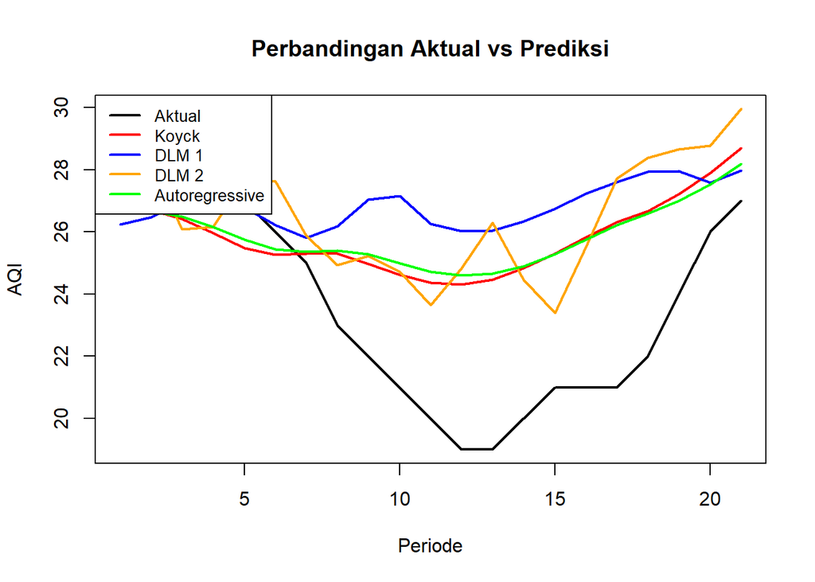

```r
par(mfrow=c(1,1))  # layout tunggal

periode <- 1:length(test$AQI)

# plot data aktual
plot(periode, test$AQI, type="l", col="black", lwd=2,
     ylim=c(min(test$AQI, fore.koyck$forecasts, fore.dlm$forecasts, fore.dlm2$forecasts, fore.ardl$forecasts),
            max(test$AQI, fore.koyck$forecasts, fore.dlm$forecasts, fore.dlm2$forecasts, fore.ardl$forecasts)),
     xlab="Periode", ylab="AQI", main="Perbandingan Aktual vs Prediksi")

# tambahkan garis prediksi masing-masing model
lines(periode, fore.koyck$forecasts, col="red", lwd=2)
lines(periode, fore.dlm$forecasts, col="blue", lwd=2)
lines(periode, fore.dlm2$forecasts, col="orange", lwd=2)
lines(periode, fore.ardl$forecasts, col="green", lwd=2)

# legenda
legend("topleft",
       legend=c("Aktual", "Koyck","DLM 1","DLM 2", "Autoregressive"),
       col=c("black","red","blue","orange","green"),
       lty=1, lwd=2,
       cex=0.85)
```